# Specialty PharmD intervention targeting adherence

Ryan Moore

Leena Choi

Department of Biostatistics

Vanderbilt University Medical Center

2022-09-09

# 1 Study Details

## 1.1 Study title

**Pharmacist Interventions to Improve Specialty Medication Adherence: A Randomized Controlled Trial**

## 1.2 Background

The effectiveness of specialty medications in complicated clinical conditions depends on adherence to therapy. Patient-tailored adherence interventions may be able to improve adherence in non-adherent patients.

## 1.3 Objectives

**Primary Objective**

- Assess effectiveness of patient-tailored intervention on improving 8-month PDC

**Secondary Objectives**

- Describe the rates and reasons for non-adherence

## 1.4 Methods

### 1.4.1 Exclusion Criteria

- PDC > 90% in previous 4 months or previous 12 months.

The PDC for the exclusion criteria was calculated in order to enrich the sample for non-adherent patients. The baseline PDC secondary outcome was calculated independently and uses the same algorithm as used to calculated the prospective PDC outcome. Due to the slightly different methods, some patient’s baseline PDCs are greater than 90%.

## 1.5 Outcomes

- 6, 8, and 12 month post-enrollment follow-up PDC
- 12 month pre-enrollment baseline PDC
- Baseline Assessment Results

## 1.6 PDC Calculations

- Medication adherence is estimated by calculating the proportion of days covered (PDC) from participants’ fill data from the electronic healthcare record.
  - Unlike other adherence estimates such as medication possession ratio, PDC accounts for oversupply and cannot be greater than 100%
  - A PDC of 1 indicates perfect adherence while a PDC of 0 indicates no use of medication.
  - $PDC=\frac{\text{Sum of days covered in timeframe}}{\text{Number of days in time frame}}$
    - Days covered within a time frame is a term used to indicate availability of a prescribed daily dose on a given day.
    - The availability of medication is tracked using a moving array of each day’s supply that accounts for overfills by moving extra medication within a fill period to the start of the first exhaustion date of the given medication
    - Oversupply is truncated at the end of the time frame and each day in the denominator is limited to have a maximum of 1 day’s supply.
- For this study, the time frame is defined as the time period from the start of the first fill to the first day of the last fill.
- Three different time-frames were specified for PDC calculations in this analysis
  - 12 month retrospective baseline PDC: The time frame starts at the first medication fill within 1 year before trial enrollment and ends at the start of the last fill prior to trial enrollment
  - 6, 8, and 12 months prospective PDC: The time frame starts at the first medication fill after trial enrollment and ends at the start of the last fill before 6, 8, or 12 months after trial enrollment.

# 2 Descriptive Statistics

## 2.1 Demographics and Characteristics

| Demographics and characteristics | Demographics and characteristics N | Demographics and characteristics *N=439* |
| --- | --- | --- |
| Age | 439 | 40 53 64 (51 ±18) |
| Sex | 439 |  |
| Male |  | 32% (140) |
| Female |  | 68% (299) |
| Race | 439 |  |
| White |  | 82.0% (360) |
| Black or African American |  | 13.4% ( 59) |
| Other |  | 2.1% ( 9) |
| NA |  | 2.5% ( 11) |
| Insurance | 439 |  |
| Commercial |  | 58.1% (255) |
| Medicare |  | 34.9% (153) |
| Medicaid |  | 7.1% ( 31) |
| None |  | 0.0% ( 0) |
| Other |  | 0.0% ( 0) |
| Medication Route | 439 |  |
| Injectable |  | 70% (307) |
| Oral |  | 30% (132) |
| Duration of Therapy | 439 |  |
| < 1 year |  | 33.0% (145) |
| >= 1 year |  | 66.5% (292) |
| NA |  | 0.5% ( 2) |
| Clinic | 439 |  |
| Adult Misc |  | 13.0% ( 57) |
| Adult Rheumatology |  | 34.6% (152) |
| Lipids |  | 17.1% ( 75) |
| MS |  | 19.6% ( 86) |
| Pediatric |  | 7.1% ( 31) |
| Pulmonary |  | 8.7% ( 38) |
| Clinic Level | 439 |  |
| High |  | 25.3% (111) |
| Medium |  | 33.3% (146) |
| Low |  | 41.2% (181) |
| NA |  | 0.2% ( 1) |
| Patient portal use | 439 |  |
| No |  | 33% (143) |
| Yes |  | 67% (296) |
| Baseline PDC 12m | 439 | 0.78 0.87 0.90 (0.81 ±0.12) |

*a* *b* *c* represent the lower quartile *a*, the median *b*, and the upper quartile *c* for continuous variables. *x ± s* represents X ± 1 SD. *N* is the number of non-missing values. Numbers after proportions are frequencies.

## 2.2 Social Determinants of Health

- SDOH data is estimated using geocoding and American Census Survey data

| Social determinants of health | Social determinants of health N | Social determinants of health *N=439* |
| --- | --- | --- |
| Distance to Care | 437 | 22 51 112 ( 85 ±123) |
| Percent Poverty | 437 | 6.9 12.0 19.6 (13.8 ± 9.2) |
| Percent No Health Insurance | 437 | 5.6 9.1 13.4 (10.0 ± 5.6) |
| Median Income | 437 | 4.2 5.3 7.6 (6.2 ±3.0) |
| Percent Highschool Education | 437 | 82.6 88.7 94.5 (88.2 ± 7.4) |
| Percent Assisted Income | 437 | 5.1 11.0 16.7 (12.4 ± 9.2) |
| Deprivation Index | 437 | 0.24 0.32 0.38 (0.31 ±0.10) |
| Percent Vacant | 437 | 5.0 8.4 13.4 (10.2 ± 8.4) |

*a* *b* *c* represent the lower quartile *a*, the median *b*, and the upper quartile *c* for continuous variables. *x ± s* represents X ± 1 SD. *N* is the number of non-missing values.

# 3 Reasons for Non-adherence

The reasons for the non-adherence for the patients that participated in the randomized trial and the reasons for the misidentified non-adherent patients (none of which are in the RCT data) are displayed below.

## 3.1 Non-adherent Patients

### 3.1.1 Total Occurrences - Non adherent

The table gives the total number of occurrences for each non-adherence reason, but does not account for patients having intersections of multiple reasons.

True non-adherent: Total count and percent of selected reasons

|  | Count (n= 299) |
| --- | --- |
| Financial | 8 (2.7%) |
| Clincial | 25 (8.4%) |
| Health Literacy or comprehension | 19 (6.4%) |
| Memory | 82 (27.4%) |
| Unreachable | 60 (20.1%) |
| Unresponsive | 32 (10.7%) |
| Pharmacy/Clinic Error | 15 (5%) |
| Social Issues | 23 (7.7%) |
| No known reasons | 35 (11.7%) |

### 3.1.2 Upset plot - Non adherent

The upset plots are an alternative to a venn diagram and can be helpful when a set size is large. This upset plot gives the total number of occurrences for each non-adherence reason in the bottom left corner of the figure and is labeled “set size”. The “intersection size” graph on the top of the figure indicates the total number of occurrences for every intersection between the different reasons. The intersection is indicated by the dots at the bottom portion of the figure. The figure is not exhaustive and excludes low count intersections.

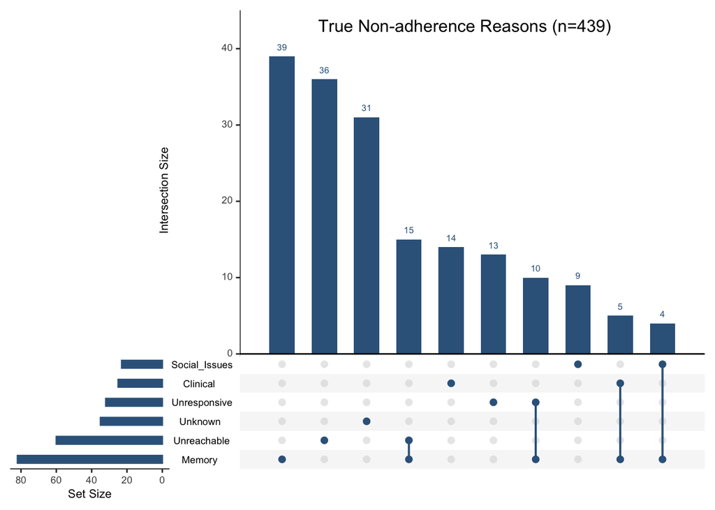

## 3.2 Misidentified Patients

775 patients were flagged as non-adherent when there was a reason for their non-adherence - these are referred to as “misidentified patients”. Two of misidentified patients were randomized into trial, but they were randomized before the cutoff date and were excluded. The following tables and charts summarize the count and patterns of the misidentified non-adherence reasons.

### 3.2.1 Total Occurences - Misidentified

The table gives the total number of occurrences for each non-adherence reason, but does not account for patients having intersections of multiple reasons.

Misidentified non-adherent: Total count and percent of selected reasons

|  | Count n=(775) |
| --- | --- |
| Clinical | 250 (32.3%) |
| Non-VUMC fill | 136 (17.5%) |
| Medication discontinuation | 167 (21.5%) |
| Drug dosage form incongruency | 29 (3.7%) |
| Temporary insurance laspse | 54 (7%) |
| Switched to alternate GPI of same med | 87 (11.2%) |
| No longer seeing VUMC | 16 (2.1%) |
| Held for pandemic | 9 (1.2%) |
| Other | 45 (5.8%) |
| Delay in starting therapy | 1 (0.1%) |
| Out of country | 0 (0%) |

### 3.2.2 Upset plot - Misidentified

The upset plots are an alternative to a venn diagram and can be helpful when a set size is large. This upset plot gives the total number of occurrences for each non-adherence reason in the bottom left corner of the figure and is labeled “set size”. The “intersection size” graph on the top of the figure indicates the total number of occurrences for every intersection between the different reasons. The intersection is indicated by the dots at the bottom portion of the figure. The figure is not exhaustive and excludes low count interestions.

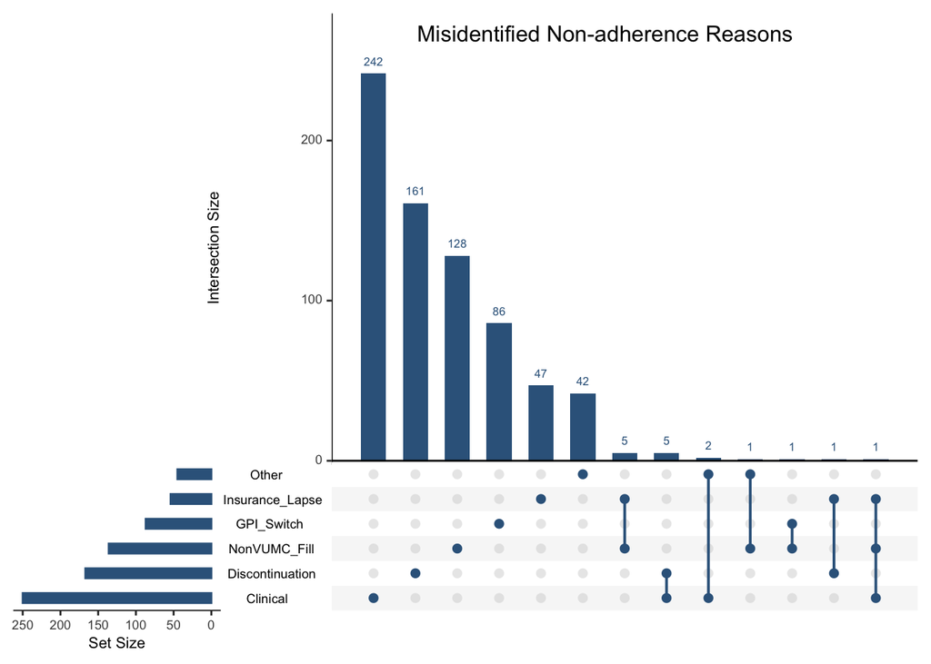

## 3.3 Reasons for non-adherence by clinic

### 3.3.1 Barplot

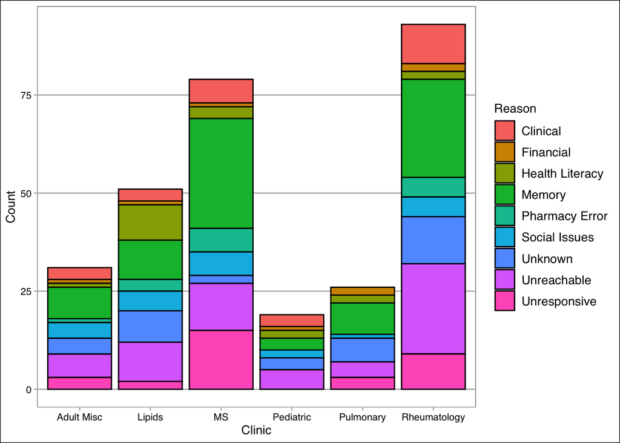

### 3.3.2 Heatmap

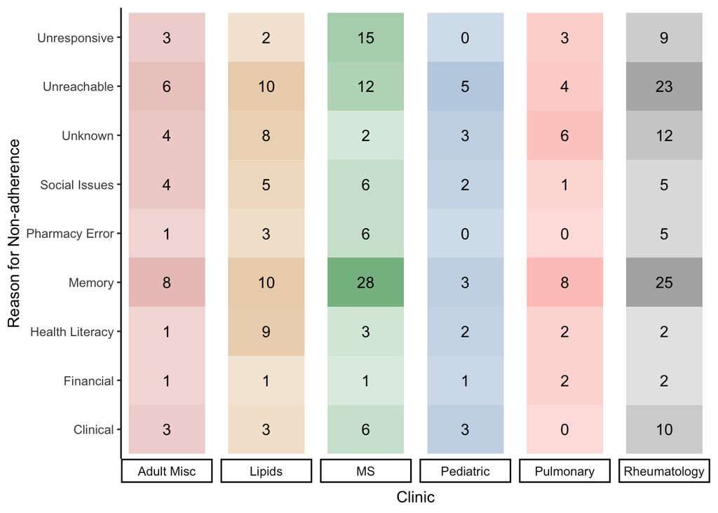

# 4 Randomized Pharmacist Intervention

## 4.1 Descriptive Statistics

### 4.1.1 Interventions

A total of 355 interventions were performed on 190 patients (29 out of the 219 patients in the intervention group did not have interventions). The distribution of the number of interventions per patient in the intervention group is displayed below.

| Interventions per patient | Interventions per patient N | Interventions per patient *N=219* |
| --- | --- | --- |
| Intervention Count | 219 | 1.0 1.0 2.0 (1.6 ±1.4) |

*a* *b* *c* represent the lower quartile *a*, the median *b*, and the upper quartile *c* for continuous variables. *x ± s* represents X ± 1 SD. *N* is the number of non-missing values.

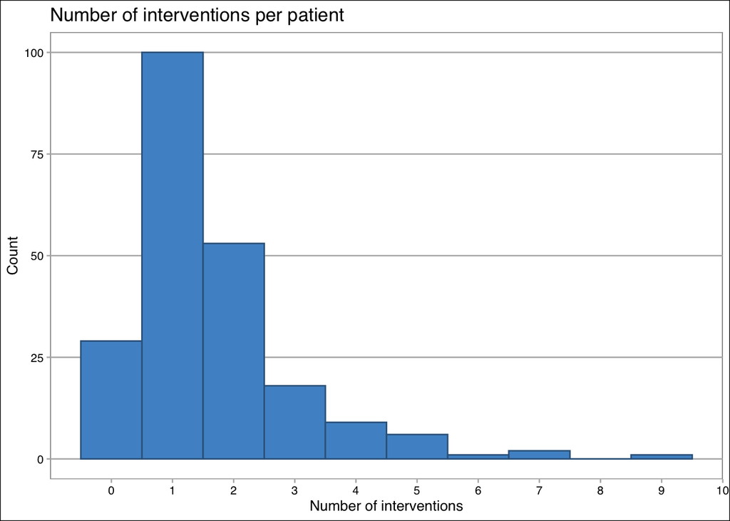

### 4.1.2 Contact attempts

| Contacts per patient in treatment group | Contacts per patient in treatment group N | Contacts per patient in treatment group *N=219* |
| --- | --- | --- |
| Contacts per patient | 219 | 2.0 5.0 10.0 ( 6.7 ± 5.6) |

*a* *b* *c* represent the lower quartile *a*, the median *b*, and the upper quartile *c* for continuous variables. *x ± s* represents X ± 1 SD. *N* is the number of non-missing values.

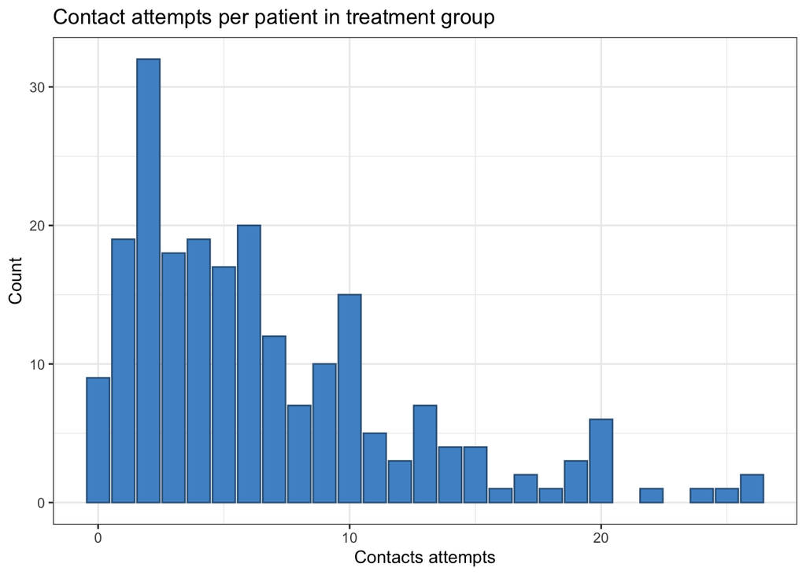

| Total count of each contact type | Total count of each contact type N | Total count of each contact type *N=1475* |
| --- | --- | --- |
| Contact type | 1475 |  |
| Mailed letter |  | 3.3% ( 49) |
| Phone call- Left voicemail |  | 34.0% (502) |
| Phone call- No voicemail or contact |  | 17.1% (252) |
| Phone call- Spoke to patient |  | 34.2% (504) |
| Sent email |  | 4.8% ( 71) |
| Sent MHAV message |  | 6.6% ( 97) |

*N* is the number of non-missing values. Numbers after proportions are frequencies.

## 4.2 Outcomes

### 4.2.1 Post-enrollment PDC

#### 4.2.1.1 Table

| Prospective PDC Measurements | Prospective PDC Measurements N | Prospective PDC Measurements Usual Care *N=220* | Prospective PDC Measurements Intervention *N=219* | Prospective PDC Measurements P-value |
| --- | --- | --- | --- | --- |
| Baseline PDC 12m | 439 | 0.78 0.86 0.89 (0.81 ±0.12) | 0.78 0.87 0.90 (0.82 ±0.12) | 0.21 |
| Prospective 6mo PDC | 397 | 0.76 0.90 0.98 (0.84 ±0.17) | 0.84 0.95 1.00 (0.90 ±0.13) | 0.003 |
| Prospective 8mo PDC | 401 | 0.75 0.88 0.97 (0.83 ±0.17) | 0.84 0.94 0.99 (0.89 ±0.13) | <0.001 |
| Prospective 12mo PDC | 402 | 0.72 0.87 0.95 (0.82 ±0.17) | 0.82 0.93 0.98 (0.88 ±0.13) | <0.001 |

*a* *b* *c* represent the lower quartile *a*, the median *b*, and the upper quartile *c* for continuous variables. *x ± s* represents X ± 1 SD. *N* is the number of non-missing values. Test used: Wilcoxon test .

#### 4.2.1.2 Density plots

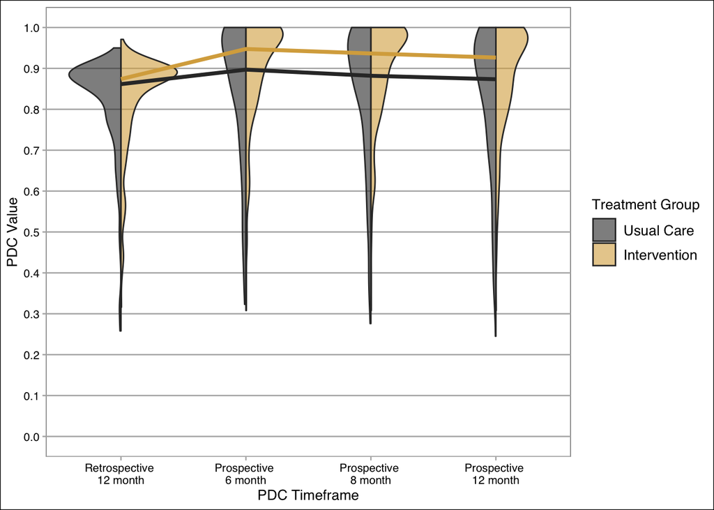

# 5 8 Month PDC Outcome

## 5.1 Univariate

| Prospective 8 Month PDC | Prospective 8 Month PDC N | Prospective 8 Month PDC Usual Care *N=220* | Prospective 8 Month PDC Intervention *N=219* | Prospective 8 Month PDC P-value |
| --- | --- | --- | --- | --- |
| Prospective 8mo PDC | 401 | 0.75 0.88 0.97 (0.83 ±0.17) | 0.84 0.94 0.99 (0.89 ±0.13) | <0.001 |

*a* *b* *c* represent the lower quartile *a*, the median *b*, and the upper quartile *c* for continuous variables. *x ± s* represents X ± 1 SD. *N* is the number of non-missing values. Test used: Wilcoxon test .

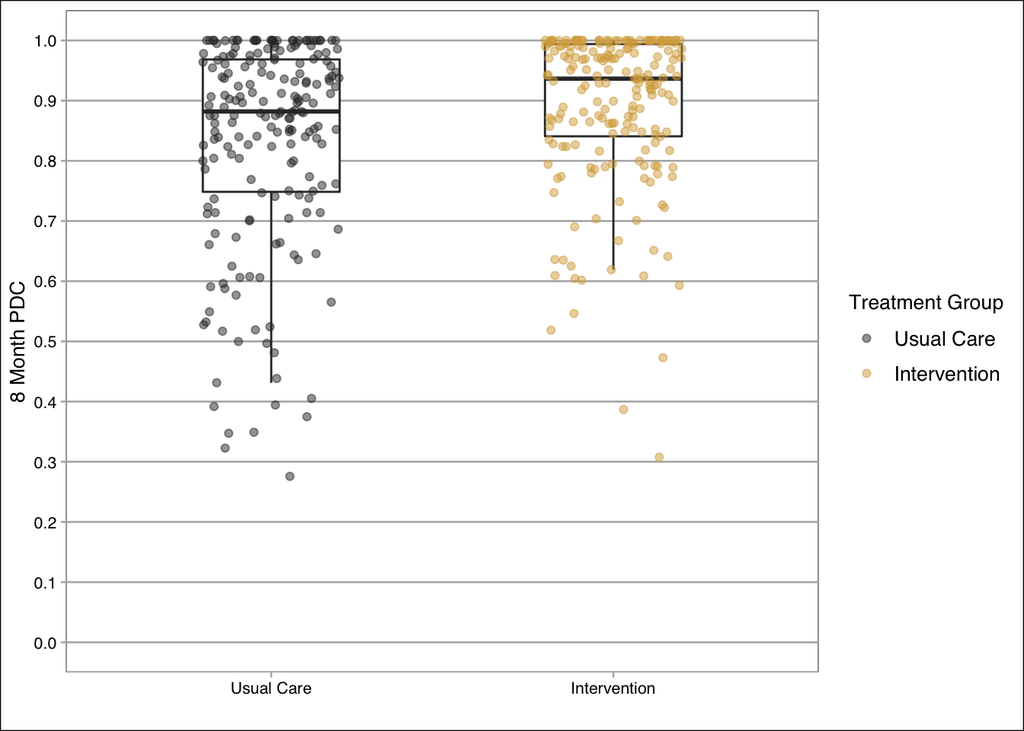

## 5.2 Ordinal logistic regression

### 5.2.1 Visualization

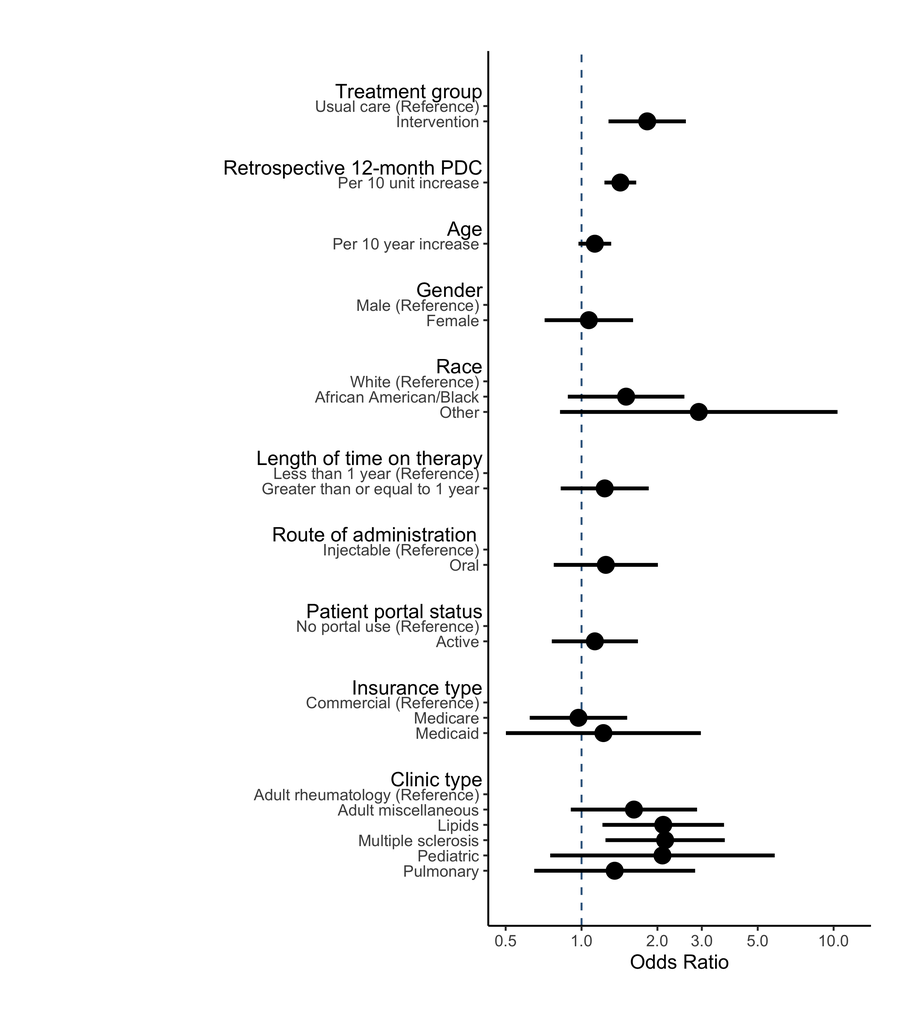

### 5.2.2 Table

| Variable | Odds Ratio | 95% Confidence interval Lower | 95% Confidence interval Upper | p-value |
| --- | --- | --- | --- | --- |
| **Treatment group (Usual care reference)** |  |  |  |  |
| Intervention | 1.82 | 1.28 | 2.59 | <0.001 |
| **12 Month Baseline PDC** |  |  |  |  |
| Per 10 unit increase | 1.43 | 1.23 | 1.65 | <0.001 |
| **Age** |  |  |  |  |
| Per 10 year increase | 1.13 | 0.97 | 1.31 | 0.111 |
| **Administration method (Injectable reference)** |  |  |  |  |
| Oral | 1.25 | 0.78 | 2.01 | 0.361 |
| **Sex (Male reference)** |  |  |  |  |
| Female | 1.07 | 0.71 | 1.60 | 0.746 |
| **Race (White reference)** |  |  |  |  |
| Black or African American | 1.50 | 0.88 | 2.56 | 0.134 |
| Other | 2.92 | 0.82 | 10.36 | 0.098 |
| **Duration of treatment (Less than one year reference)** |  |  |  |  |
| Greater than or equal to 1 yearr | 1.24 | 0.83 | 1.85 | 0.302 |
| **Insurance (Commercial reference)** |  |  |  |  |
| Medicare | 0.97 | 0.62 | 1.52 | 0.901 |
| Medicaid | 1.22 | 0.50 | 2.97 | 0.661 |
| **Clinic (Rheumatology reference)** |  |  |  |  |
| Adult Miscellaneous | 1.61 | 0.91 | 2.87 | 0.104 |
| Lipids | 2.11 | 1.21 | 3.67 | 0.008 |
| Multiple Sclerosis | 2.15 | 1.24 | 3.70 | 0.006 |
| Pediatric | 2.09 | 0.75 | 5.84 | 0.158 |
| Pulmonary | 1.35 | 0.65 | 2.82 | 0.420 |
| **Online portal use (Inactive reference)** |  |  |  |  |
| Active | 1.13 | 0.76 | 1.67 | 0.545 |

## 5.3 8 month PDC by treatment group and clinic

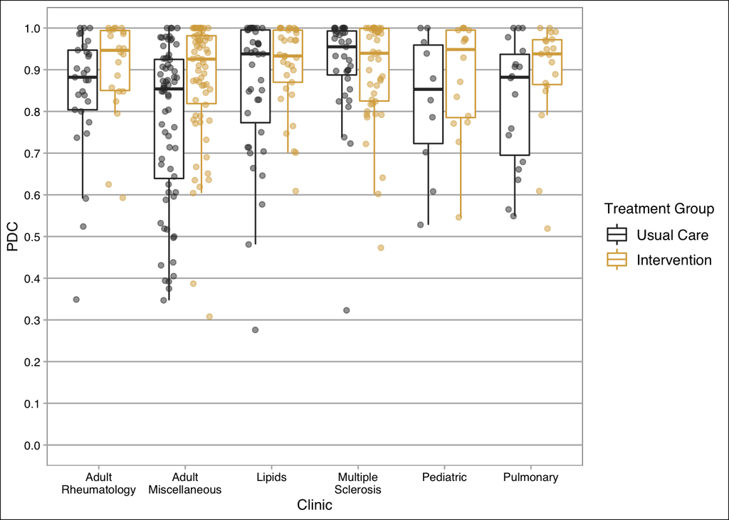

### 5.3.1 Median difference in PDC pre and post-intervention by clinic

Median difference in Post/Pre PDC by treatment group and clinic

| Clinic | Usual Care | Intervention |
| --- | --- | --- |
| Adult Rheumatology | 0.02 (n=78) | 0.07 (n=74) |
| Adult Misc | 0.03 (n=32) | 0.09 (n=25) |
| MS | 0.09 (n=39) | 0.1 (n=47) |
| Lipids | 0.08 (n=39) | 0.09 (n=36) |
| Pulmonary | 0.05 (n=18) | 0.09 (n=20) |
| Pediatric | 0.04 (n=14) | 0.07 (n=17) |
| All | 0.06 | 0.09 |

## 5.4 PDC by timeframe and clinic

### 5.4.1 Usual Care

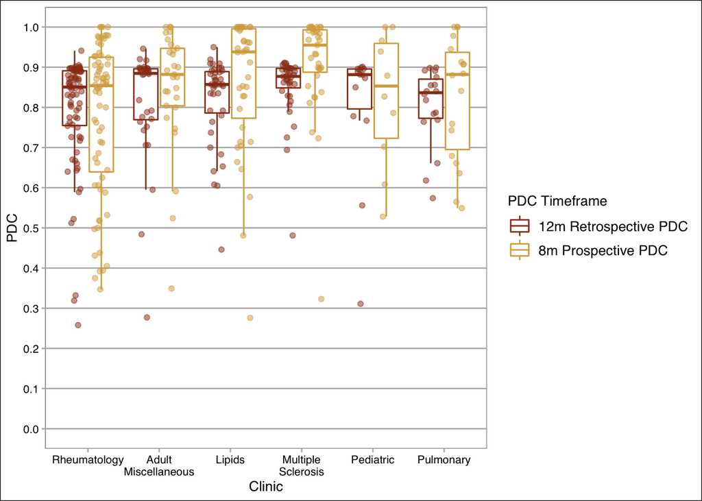

### 5.4.2 Intervention

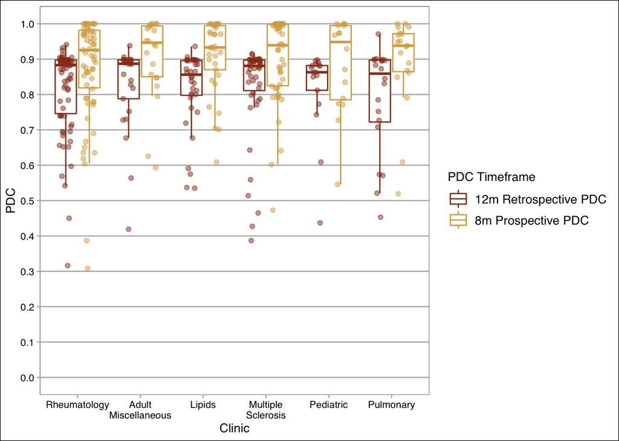

### 5.4.3 Overall

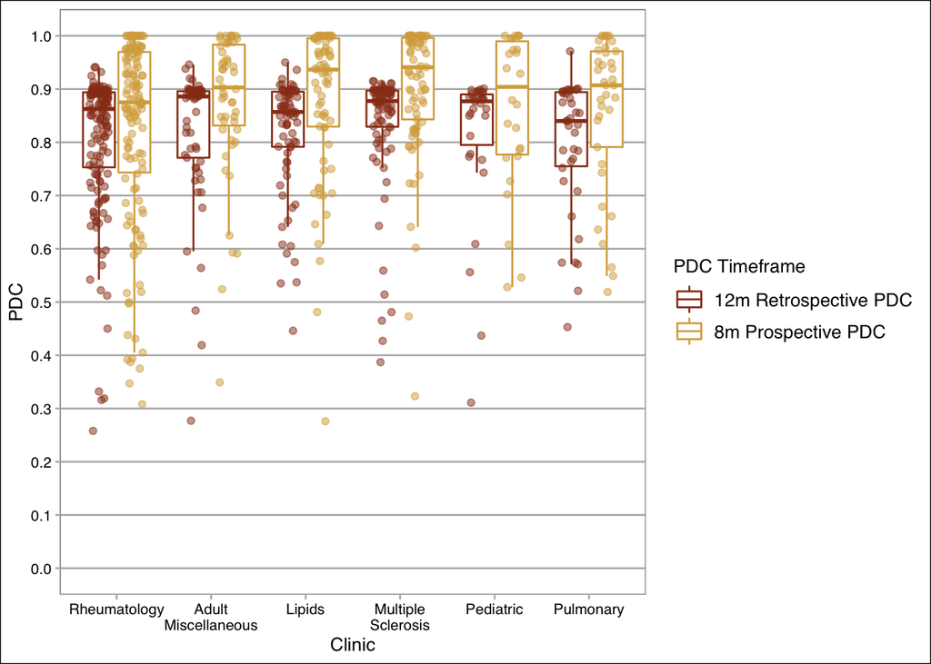

## 5.5 PDC by reason for non-adherence in Intervention group

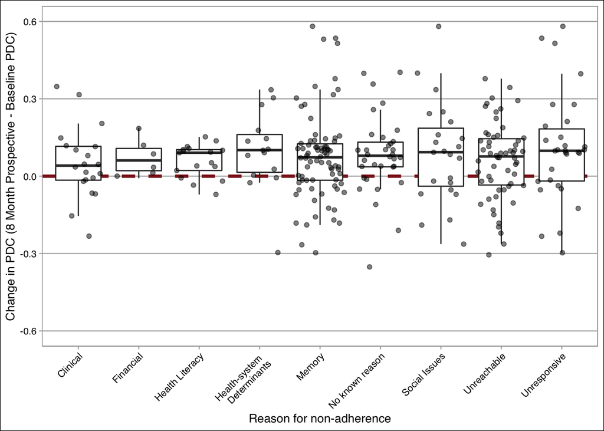